# Project1_Iris_Dimensionality-reduction-and-clustering_E.Humbert

[ENG]

PROJECT 1 : IRIS - DIMENSIONALITY REDUCTION AND CLUSTERING

[FR]

PROJET 1 : IRIS - RÉDUCTION DE LA DIMENSIONNALITÉ ET CLUSTERING

```python
# import packages
import pandas as pd
import numpy as np
import matplotlib.pyplot as plt
import seaborn as sns
from sklearn.decomposition import PCA
from sklearn.preprocessing import StandardScaler

# Import Packages for 3D Graphs
from mpl_toolkits.mplot3d import Axes3D
import plotly.express as px
import plotly.graph_objects as go
```

[ENG]

1. Load IRIS dataset into your environment, and represent the individuals on the following axes in three dimensions axes: Sepal.Length, Petal.Length, and Sepal.Width.

[FR]

1. Chargez dans votre environnement le jeu de données IRIS, et représentez en trois dimensions (comme dans la Figure 1) les individus sur les axes suivants : Sepal.Length,

Petal.Length, et Sepal.Width.

```python
# Open IRIS dataset
iris_df= pd.read_csv("C://Users//emmhu//OneDrive//Documents//E-LEARNING//DU DATA ANALYST//3_RD & Clustering//Données//Datasets//iris.csv")
iris_df.head()
```

|  | sepal.length | sepal.width | petal.length | petal.width | variety |
| --- | --- | --- | --- | --- | --- |
| 0 | 5.1 | 3.5 | 1.4 | 0.2 | Setosa |
| 1 | 4.9 | 3.0 | 1.4 | 0.2 | Setosa |
| 2 | 4.7 | 3.2 | 1.3 | 0.2 | Setosa |
| 3 | 4.6 | 3.1 | 1.5 | 0.2 | Setosa |
| 4 | 5.0 | 3.6 | 1.4 | 0.2 | Setosa |

```python
# Convert 'variety' column to categorical type
iris_df['variety'] = pd.Categorical(iris_df['variety'])
```

```python
# Separate features from the target variable
features = iris_df[['sepal.length', 'sepal.width', 'petal.length', 'petal.width']]
target = iris_df['variety'] # I keep 'variety' column to use it for legend later
```

```python
# Create a PCA model with 3 components
pca= PCA(n_components= 3)
pca_result = pca.fit_transform(features)
```

```python
# Create a dataframe from pca_result
pca_df_3d_unscaled= pd.DataFrame(data=pca_result, columns=['PC1', 'PC2', 'PC3'])

pca_df_3d_unscaled.head()
```

|  | PC1 | PC2 | PC3 |
| --- | --- | --- | --- |
| 0 | -2.684126 | 0.319397 | -0.027915 |
| 1 | -2.714142 | -0.177001 | -0.210464 |
| 2 | -2.888991 | -0.144949 | 0.017900 |
| 3 | -2.745343 | -0.318299 | 0.031559 |
| 4 | -2.728717 | 0.326755 | 0.090079 |

```python
# Add 'variety' column to use later forlegend
pca_df_3d_unscaled['variety']= target

# Create a color mapping dictionnary based on the variety
colors = {'Setosa': 'red', 'Versicolor': 'green', 'Virginica': 'blue'}

# Add a 'color' column
pca_df_3d_unscaled['color'] = pca_df_3d_unscaled['variety'].map(colors)

pca_df_3d_unscaled.head()
```

|  | PC1 | PC2 | PC3 | variety | color |
| --- | --- | --- | --- | --- | --- |
| 0 | -2.684126 | 0.319397 | -0.027915 | Setosa | red |
| 1 | -2.714142 | -0.177001 | -0.210464 | Setosa | red |
| 2 | -2.888991 | -0.144949 | 0.017900 | Setosa | red |
| 3 | -2.745343 | -0.318299 | 0.031559 | Setosa | red |
| 4 | -2.728717 | 0.326755 | 0.090079 | Setosa | red |

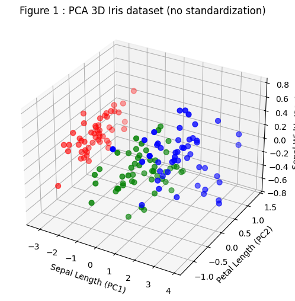

```python
# Create a 3D scatter plot
fig = plt.figure(figsize=(12, 6))
ax = fig.add_subplot(111, projection='3d')  # Correct way to create a 3D subplot

# Scatter plot
ax.scatter(pca_df_3d_unscaled["PC1"],
           pca_df_3d_unscaled["PC2"],
           pca_df_3d_unscaled["PC3"],
           c=pca_df_3d_unscaled['color'],  # Color based on variety
           s=40,
           depthshade=True)

# Add labels
ax.set_xlabel('Sepal Length (PC1)')
ax.set_ylabel('Petal Length (PC2)')
ax.set_zlabel('Sepal Width (PC3)')
ax.set_title('Figure 1 : PCA 3D Iris dataset (no standardization)')

plt.savefig('Figure1_PCA_3D_iris_dataset_(no_standardization).png', dpi=300)

# Show the plot
plt.show()
```

### Figure 1: PCA 3D visualization of the Iris dataset (no standardization)

This figure presents a 3D scatter plot of the Iris dataset after applying **Principal Component Analysis (PCA)** without standardizing the features.

[ENG]

2. Repeat the previous step, but after centring and reducing the corresponding variables.

[FR]

2. Répétez l’étape précédente, mais après avoir centré puis réduit les variables correspondantes.

```python
# Standardizing features (centring and reducing)
scaler= StandardScaler()
scaled_features= scaler.fit_transform(features)
```

```python
# Create a PCA model with 3 components
pca= PCA(n_components= 3)

pca_result= pca.fit_transform(scaled_features)
```

```python
# Create a dataframe from pca_result
pca_df_3d_scaled= pd.DataFrame(data=pca_result, columns=['PC1', 'PC2', 'PC3'])


pca_df_3d_scaled.head()
```

|  | PC1 | PC2 | PC3 |
| --- | --- | --- | --- |
| 0 | -2.264703 | 0.480027 | 0.127706 |
| 1 | -2.080961 | -0.674134 | 0.234609 |
| 2 | -2.364229 | -0.341908 | -0.044201 |
| 3 | -2.299384 | -0.597395 | -0.091290 |
| 4 | -2.389842 | 0.646835 | -0.015738 |

```python
# Add 'variety' column to use later for legend
pca_df_3d_scaled['variety']= target

# Create a color mapping dictionnary based on the variety
colors = {'Setosa': 'red', 'Versicolor': 'green', 'Virginica': 'blue'}

# Add a 'color' column
pca_df_3d_scaled['color'] = pca_df_3d_scaled['variety'].map(colors)

pca_df_3d_scaled.head()
```

|  | PC1 | PC2 | PC3 | variety | color |
| --- | --- | --- | --- | --- | --- |
| 0 | -2.264703 | 0.480027 | 0.127706 | Setosa | red |
| 1 | -2.080961 | -0.674134 | 0.234609 | Setosa | red |
| 2 | -2.364229 | -0.341908 | -0.044201 | Setosa | red |
| 3 | -2.299384 | -0.597395 | -0.091290 | Setosa | red |
| 4 | -2.389842 | 0.646835 | -0.015738 | Setosa | red |

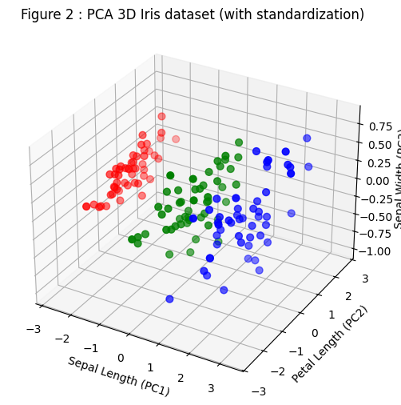

```python
# Create a 3D scatter plot
fig = plt.figure(figsize=(12, 6))
ax = fig.add_subplot(111, projection='3d')  # Correct way to create a 3D subplot

# Scatter plot
ax.scatter(pca_df_3d_scaled["PC1"],
           pca_df_3d_scaled["PC2"],
           pca_df_3d_scaled["PC3"],
           c=pca_df_3d_scaled['color'],  # Color based on variety
           s=40,
           depthshade=True)

# Add labels
ax.set_xlabel('Sepal Length (PC1)')
ax.set_ylabel('Petal Length (PC2)')
ax.set_zlabel('Sepal Width (PC3)')
ax.set_title('Figure 2 : PCA 3D Iris dataset (with standardization)')

plt.savefig('Figure2_PCA_3D_iris_dataset_(with_standardization).png', dpi=300)

plt.show()
```

### Figure 2: PCA 3D visualization of the Iris dataset (with standardization)

This figure shows a 3D scatter plot of the Iris dataset after applying **Principal Component Analysis (PCA)** with feature **standardization** (mean=0, variance=1).

[ENG]

3. Perform a principal component analysis, then display the individuals on the first two components. You will choose different colours according to the type of iris species considered, as in Figure 2. Carry out this step twice: once without standardising the data, and once with. From now on, you will always work with reduced centred variables.

[FR]

3. Réalisez une analyse en composantes principales, puis affichez les individus sur les deux premières composantes. Vous choisirez des couleurs différentes selon le type d’espèce d’iris considéré, comme en Figure 2. Vous réaliserez cette étape en deux fois : une première fois sans standardisation des données, une seconde fois avec. A partir de maintenant, vous travaillerez toujours avec les variables centrées réduites.

```python
# Create a PCA model with 2 components
pca= PCA(n_components= 2)
pca_result = pca.fit_transform(features)
```

```python
# Create a dataframe from pca_result
pca_df_2d_unscaled= pd.DataFrame(data=pca_result, columns=['PC1', 'PC2'])
pca_df_2d_unscaled['variety'] = target  # Add 'variety' column for legend

pca_df_2d_unscaled.head()
```

|  | PC1 | PC2 | variety |
| --- | --- | --- | --- |
| 0 | -2.684126 | 0.319397 | Setosa |
| 1 | -2.714142 | -0.177001 | Setosa |
| 2 | -2.888991 | -0.144949 | Setosa |
| 3 | -2.745343 | -0.318299 | Setosa |
| 4 | -2.728717 | 0.326755 | Setosa |

```python
# Create a 2D scatter plot using Plotly for PCA without standardization (version 1)
fig = px.scatter(
    pca_df_2d_unscaled,
    x='PC1',
    y='PC2',
    color='variety',  # Use the original variety for colors
    title='Figure 3 : PCA 2D Iris dataset (no standardization)',
    labels={'PC1': 'sepal length', 'PC2': 'petal length'},
    color_discrete_sequence=px.colors.qualitative.Set1  # Use a qualitative color scale
)

fig.write_html('Figure3_PCA_2D_iris_dataset_(with_plotly_no_standardization).html')


# Show the plot
fig.show()
```

This figure shows a 2D scatter plot of the Iris dataset after applying **Principal Component Analysis (PCA)** without feature standardization.

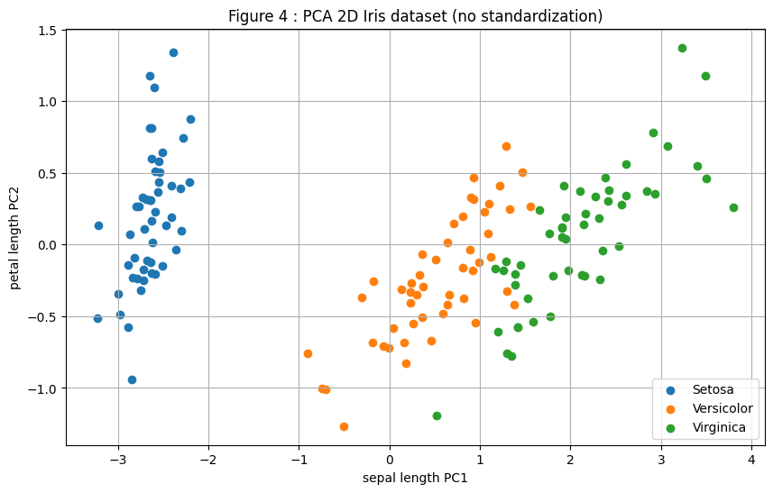

```python
# Create a 2D scatter plot of PCA without Plotly and without standardization (version 2)
plt.figure(figsize=(10, 6))
for variety in pca_df_2d_unscaled['variety'].cat.categories:
    subset = pca_df_2d_unscaled[pca_df_2d_unscaled['variety'] == variety]
    plt.scatter(subset['PC1'], subset['PC2'], label=variety)

plt.xlabel('sepal length PC1')
plt.ylabel('petal length PC2')
plt.title('Figure 4 : PCA 2D Iris dataset (no standardization)')
plt.legend()
plt.grid()

plt.savefig('Figure4_PCA_2D_iris_dataset_(no_standardization)_version2.png', dpi=300)

plt.show()
```

### Figure 4 : PCA 2D visualization of the Iris dataset (no standardization)

This figure shows a 2D scatter plot of the Iris dataset after applying **Principal Component Analysis (PCA)** without feature standardization.

```python
# Standardizing features (centring and reducing)
scaler= StandardScaler()
scaled_features= scaler.fit_transform(features)
```

```python
# Create PCA model with 2 components
pca= PCA(n_components= 2)
pca_result = pca.fit_transform(scaled_features)
```

```python
# Create a dataframe from pca_result
pca_df_2d_scaled= pd.DataFrame(data=pca_result, columns=['PC1', 'PC2'])
pca_df_2d_scaled['variety'] = target  # # Add 'variety' column for legend

pca_df_2d_scaled.head()
```

|  | PC1 | PC2 | variety |
| --- | --- | --- | --- |
| 0 | -2.264703 | 0.480027 | Setosa |
| 1 | -2.080961 | -0.674134 | Setosa |
| 2 | -2.364229 | -0.341908 | Setosa |
| 3 | -2.299384 | -0.597395 | Setosa |
| 4 | -2.389842 | 0.646835 | Setosa |

```python
# Create a 2D scatter plot using Plotly for PCA with standardization (version 1)
fig = px.scatter(
    pca_df_2d_scaled,
    x='PC1',
    y='PC2',
    color='variety',  # Use the original variety for colors
    title='Figure 5 : PCA 2D Iris dataset (with Plotly and stardardization)',
    labels={'PC1': 'sepal length', 'PC2': 'petal length'},
    color_discrete_sequence=px.colors.qualitative.Set1  # Use a qualitative color scale
)

# Save the interactive HTML file
fig.write_html('Figure5_PCA_2D_iris_dataset_(with_plotly_and_standardization).html')

# Show the plot
fig.show()
```

This figure presents a 2D scatter plot of the Iris dataset after applying **Principal Component Analysis (PCA)** with **feature standardization** (using Plotly for visualization).

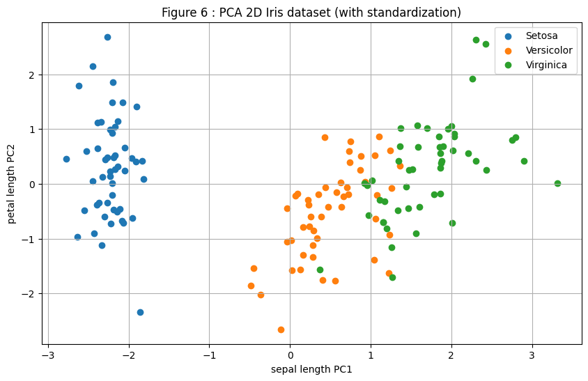

```python
# Create a 2D scatter plot of PCA without Plotly, with standardization (version 2)
plt.figure(figsize=(10, 6))
for variety in pca_df_2d_scaled['variety'].cat.categories:
    subset = pca_df_2d_scaled[pca_df_2d_scaled['variety'] == variety]
    plt.scatter(subset['PC1'], subset['PC2'], label=variety)

plt.xlabel('sepal length PC1')
plt.ylabel('petal length PC2')
plt.title('Figure 6 : PCA 2D Iris dataset (with standardization)')
plt.legend()
plt.grid()

plt.savefig('Figure6_PCA_2D_iris_dataset_(with_standardization)_version2.png', dpi=300)

plt.show()
```

```python
# 4. Calculez deux à deux les corrélations entre les différentes variables du jeu de données (en anglais : pairwise correlations).
# Représentez ces corrélations sous la forme d’un corrélogramme de votre choix (par ex., avec des bulles et des couleurs).
# L’objectif est de vous montrer la difficulté à représenter de cette manière l’intégralité des relations entre variables.

# 4. Calculate the pairwise correlations between the different variables in the dataset.
# Represent these correlations in the form of a correlogram of your choice (e.g. with bubbles and colours).
# The aim is to show you how difficult it is to represent all the relationships between variables in this way.
```

[ENG]

4. Calculate the pairwise correlations between the different variables in the dataset. Represent these correlations in the form of a correlogram of your choice (for example with bubbles and colours). The aim is to show you how difficult it is to represent all the relationships between variables in this way.

[FR]

4. Calculez deux à deux les corrélations entre les différentes variables du jeu de données (en anglais : pairwise correlations). Représentez ces corrélations sous la forme d’un corrélogramme de votre choix (par exemple, avec des bulles et des couleurs). L’objectif est de vous montrer la difficulté à représenter de cette manière l’intégralité des relations entre variables.

```python
from scipy.stats import pearsonr
```

```python
# Standardizing features (centring and reducing)
scaler= StandardScaler()
scaled_features= scaler.fit_transform(features)
```

```python
# Create a PCA model with 3 components
pca= PCA(n_components= 3)

pca_result= pca.fit_transform(scaled_features)
```

```python
# Create a dataframe from pca_result
correlation_df_3= pd.DataFrame(data=pca_result, columns=['PC1', 'PC2', 'PC3'])

correlation_df_3.head()
```

|  | PC1 | PC2 | PC3 |
| --- | --- | --- | --- |
| 0 | -2.264703 | 0.480027 | 0.127706 |
| 1 | -2.080961 | -0.674134 | 0.234609 |
| 2 | -2.364229 | -0.341908 | -0.044201 |
| 3 | -2.299384 | -0.597395 | -0.091290 |
| 4 | -2.389842 | 0.646835 | -0.015738 |

```python
# Calculate correlation matrix for all PCA pairs
correlation_matrix = correlation_df_3.corr()
```

```python
# Print the correlation matrix
print("Correlation matrix:\n", correlation_matrix)
```

```
Correlation matrix:
               PC1           PC2           PC3
PC1  1.000000e+00  2.117851e-16  6.333271e-17
PC2  2.117851e-16  1.000000e+00 -1.091935e-15
PC3  6.333271e-17 -1.091935e-15  1.000000e+00
```

```python
# Original values
values = [2.117851e-16, 6.333271e-17, -1.091935e-15]

# Convert to a more readable format (scientific notation with 2 decimal places)
readable_values_sci = [f"{v:.2e}" for v in values]

# Convert to decimal format for very small values
readable_values_decimal = [f"{v:.10f}" for v in values]

print("Scientific Notation:", readable_values_sci)
print("Decimal Format:", readable_values_decimal)
```

```
Scientific Notation: ['2.12e-16', '6.33e-17', '-1.09e-15']
Decimal Format: ['0.0000000000', '0.0000000000', '-0.0000000000']
```

## Components of the Correlation Matrix

### Diagonal Values

- The diagonal elements of the matrix (equal to 1.000000e+00) represent the correlation of each principal component with itself.
- A correlation of 1 indicates a perfect positive relationship: PC1 is perfectly correlated with PC1, PC2 with PC2, and PC3 with PC3.

### Off-Diagonal Values

- The off-diagonal elements indicate the correlation between different principal components:
  - **PC1 and PC2**: 2.117851e-16 → extremely low correlation (essentially zero).
  - **PC1 and PC3**: 6.333271e-17 → extremely low correlation.
  - **PC2 and PC3**: -1.091935e-15 → extremely low correlation.
- Simplified representation:
  - PC1 and PC2: 2.12 × 10⁻¹⁶
  - PC1 and PC3: 6.33 × 10⁻¹⁷
  - PC2 and PC3: −1.09 × 10⁻¹⁵
- Decimal notation:
  - PC1 and PC2: 0.000000000000000212
  - PC1 and PC3: 0.0000000000000000633
  - PC2 and PC3: -0.00000000000000109

### Interpretation

- The very small off-diagonal values confirm that the principal components are effectively uncorrelated.
- Each principal component captures a distinct dimension of variability within the data.
- This result is ideal for Principal Component Analysis (PCA), as it ensures that the components convey independent information.

### Dimensionality Reduction Implications

- Since the principal components are largely uncorrelated, it is reasonable to reduce the dimensionality of the dataset without significant information loss.
- In this case, using only the first two components (PC1 and PC2) could capture most of the meaningful variability.

### Summary

- **Values close to 1**: Strong positive correlation.
- **Values close to -1**: Strong negative correlation.
- **Values around 0**: Little to no linear correlation.

In conclusion, the correlation matrix supports the effectiveness of the PCA, confirming that the extracted components are well separated and suitable for dimensionality reduction.

```python
# Pearson correlation between features (by pair) : Assigner la colonne PC1 du dataframe correlation_df_3 : sepal length
sepal_length_pc1= correlation_df_3["PC1"]

# Pearson correlation between features (by pair): Assigner la colonne PC2 du dataframe correlation_df_3 : petal length
petal_length_pc2= correlation_df_3["PC2"]
```

```python
# Calculate Pearson correlation for sepal length (PC1) VS petal length (PC2)
correlation, pvalue= pearsonr(correlation_df_3["PC1"],correlation_df_3["PC2"])

print(correlation, pvalue)
```

```
2.4214300269748135e-16 0.9999999999999994
```

```python
# Add 'variety' column to use later as legend
correlation_df_3['variety']= target

# Create a color mapping dictionnary based on the variety
colors = {'Setosa': 'red', 'Versicolor': 'green', 'Virginica': 'blue'}

# Add a 'color' column
correlation_df_3['color'] = correlation_df_3['variety'].map(colors)

correlation_df_3.head()
```

|  | PC1 | PC2 | PC3 | variety | color |
| --- | --- | --- | --- | --- | --- |
| 0 | -2.264703 | 0.480027 | 0.127706 | Setosa | red |
| 1 | -2.080961 | -0.674134 | 0.234609 | Setosa | red |
| 2 | -2.364229 | -0.341908 | -0.044201 | Setosa | red |
| 3 | -2.299384 | -0.597395 | -0.091290 | Setosa | red |
| 4 | -2.389842 | 0.646835 | -0.015738 | Setosa | red |

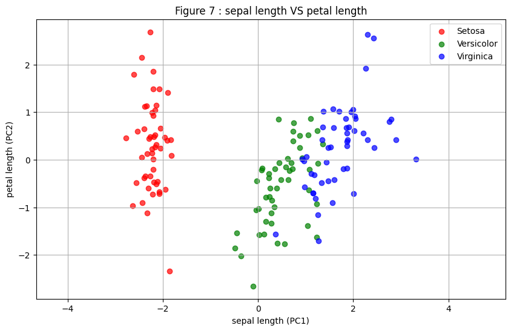

```python
# Create a scatter plot sepal length VS petal length
plt.figure(figsize=(10, 6))
for variety, color in colors.items():
    subset = correlation_df_3[correlation_df_3['variety'] == variety]
    plt.scatter(subset["PC1"],subset["PC2"],label=variety,color=color,alpha=0.7)

plt.axis('equal')

plt.title('Figure 7 : sepal length VS petal length')
plt.xlabel('sepal length (PC1)')
plt.ylabel('petal length (PC2)')
plt.legend()
plt.grid()

plt.savefig('Figure7_sepal_length_VS_petal_length.png', dpi=300)

plt.show()
```

### Figure 7: Sepal length vs Petal length (PCA components)

```python
# Correlation Pearson between features (by pair): Assigner la colonne PC3 du dataframe correlation_df_3 : sepal width
petal_width_pc3= correlation_df_3["PC3"]
```

```python
# Calculate Pearson correlation for sepal length (PC1) VS sepal width (PC3) pair
correlation, pvalue= pearsonr(correlation_df_3["PC1"],correlation_df_3["PC3"])

print(correlation, pvalue)
```

```
7.37257477290143e-17 0.9999999999999991
```

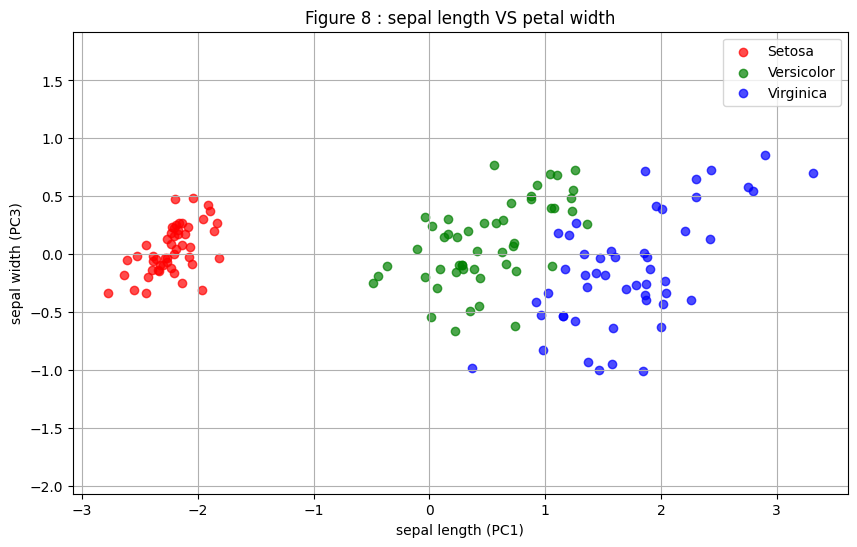

```python
# Create a scatter plot of sepal length VS sepal length
plt.figure(figsize=(10, 6))
for variety, color in colors.items():
    subset = correlation_df_3[correlation_df_3['variety'] == variety]
    plt.scatter(subset["PC1"], subset["PC3"], label=variety, color=color, alpha=0.7)

plt.axis('equal')

plt.title('Figure 8 : sepal length VS petal width')
plt.xlabel('sepal length (PC1)')
plt.ylabel('sepal width (PC3)')
plt.legend()
plt.grid()

plt.savefig('Figure8_sepal_length_VS_petal_width.png', dpi=300)

plt.show()
```

- Each point represents an observation, colored by species: **Setosa** (red), **Versicolor** (green), and **Virginica** (blue).
- **Setosa** forms a compact and distinct cluster, separated from the other species along the PC1 axis.
- **Versicolor** and **Virginica** show partial overlap but are relatively distinguishable along both PC1 and PC3.
- The plot illustrates that the third principal component (PC3) adds useful information to further differentiate species beyond what PC1 alone captures.

```python
# Calculate Pearson correlation for petal length (PC2) VS sepal width (PC3) pair
correlation, pvalue= pearsonr(correlation_df_3["PC2"],correlation_df_3["PC3"])

print(correlation, pvalue)
```

```
-1.079187737437759e-15 0.9999999999999896
```

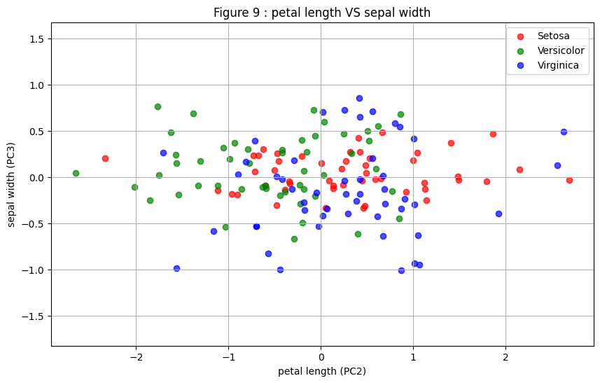

```python
# Create a scatter plot for petal length VS petal width
plt.figure(figsize=(10, 6))
for variety, color in colors.items():
    subset = correlation_df_3[correlation_df_3['variety'] == variety]
    plt.scatter(subset["PC2"], subset["PC3"], label=variety, color=color, alpha=0.7)

plt.axis('equal')

plt.title('Figure 9 : petal length VS sepal width')
plt.xlabel('petal length (PC2)')
plt.ylabel('sepal width (PC3)')
plt.legend()
plt.grid()

plt.savefig('Figure9_petal_length_VS_sepal_width.png', dpi=300)

plt.show()
```

### Figure 9: Petal length vs Sepal width (PCA components)

This figure displays a 2D scatter plot comparing **petal length (PC2)** and **sepal width (PC3)** after applying **Principal Component Analysis (PCA)** on the Iris dataset.

- Each point represents a flower, colored by species: **Setosa** (red), **Versicolor** (green), and **Virginica** (blue).
- In this projection, the clusters of species are less clearly separated compared to earlier figures.
- There is significant overlap between the three species, especially between **Versicolor** and **Virginica**.
- This plot highlights that PC2 and PC3 alone are less effective at distinguishing species compared to PC1.
- It emphasizes the importance of the first principal component (PC1) in explaining the major variance in the dataset.

[ENG]

5. Use Iris to draw a correlation circle. Which variables appear to be the most correlated, according to what you have obtained in the previous step, and how does this strong correlation appear in the correlation circle ?

[FR]

5. Représentez maintenant avec Iris un cercle des corrélations. Quelles sont les variables qui semble les plus corréléees, d’après ce que vous avez obtenu à l’étape précédente, et comment cette forte corrélation se matérialise-t-elle dans le cercle des corrélations ?

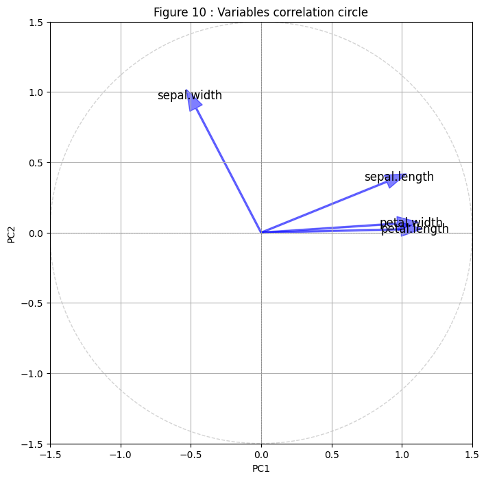

```python
# Separate the features and the target variable
features = iris_df[['sepal.length', 'sepal.width', 'petal.length', 'petal.width']]
target = iris_df['variety']  # Assuming 'variety' is the column name for species

# Standardizing features (centring and reducing)
scaler = StandardScaler()
scaled_features = scaler.fit_transform(features)

# Apply PCA to reduce to 2 dimensions
pca = PCA(n_components=2)
pca_result = pca.fit_transform(scaled_features)

# Create a DataFrame with the PCA results
pca_df = pd.DataFrame(data=pca_result, columns=['PC1', 'PC2'])
pca_df['variety'] = target  # Add the original variety for labeling

# Calculate loadings for the PCA
loadings = pca.components_.T * np.sqrt(pca.explained_variance_)
loadings_df = pd.DataFrame(loadings, index=features.columns, columns=['PC1', 'PC2'])

# Plotting the correlation circle
def plot_correlation_circle(loadings_df):
    plt.figure(figsize=(8, 8))

    # Create the circle
    circle = plt.Circle((0, 0),1.5, color='lightgrey', fill=False, linestyle='--')
    plt.gca().add_artist(circle)

    # Plot loadings
    for i in range(loadings_df.shape[0]):
        plt.arrow(0, 0, loadings_df.iloc[i, 0], loadings_df.iloc[i, 1],
                  color='b', alpha=0.5, width=0.01, head_width=0.1)
        plt.text(loadings_df.iloc[i, 0] * 1.1, loadings_df.iloc[i, 1] * 1.1, loadings_df.index[i],
                 fontsize=12, ha='center', va='center')

    plt.xlim(-1.5, 1.5)
    plt.ylim(-1.5, 1.5)
    plt.axhline(0, color='grey', lw=0.5, ls='--')
    plt.axvline(0, color='grey', lw=0.5, ls='--')
    plt.title('Figure 10 : Variables correlation circle')
    plt.xlabel('PC1')
    plt.ylabel('PC2')
    plt.grid()
    plt.gca().set_aspect('equal', adjustable='box')
    plt.savefig('Figure10_variables_correlation_circle.png')  # Save the figure
    plt.show()

# Call the function to plot the correlation circle
plot_correlation_circle(loadings_df)
```

### Figure 10: Variables correlation circle (PCA)

This figure shows the **correlation circle** (also called **correlation plot**) for the Iris dataset after applying **Principal Component Analysis (PCA)**.

[ENG]

6. Represent the biplot, with both the variables and the individuals. How much of the variance is represented on the plane represented?

[FR]

6. Représentez cette fois le biplot, avec a la fois les variables, et les individus. Quelle part de la variance est-elle représentée sur le plan représenté ?

```python
# Add 'variety' column to use later as legend
pca_df['variety']= target
```

```python
# Create a dictionnary of color mapping based on variety
colors = {'Setosa': 'red', 'Versicolor': 'green', 'Virginica': 'blue'}

pca_df.head()
```

|  | PC1 | PC2 | variety |
| --- | --- | --- | --- |
| 0 | -2.264703 | 0.480027 | Setosa |
| 1 | -2.080961 | -0.674134 | Setosa |
| 2 | -2.364229 | -0.341908 | Setosa |
| 3 | -2.299384 | -0.597395 | Setosa |
| 4 | -2.389842 | 0.646835 | Setosa |

```python
import matplotlib.patches as mpatches
```

```python
# Standardizing features (centring and reducing)
scaler = StandardScaler()
scaled_features = scaler.fit_transform(features)

# Apply PCA to reduce to 2 dimensions
pca = PCA(n_components=2)
pca_result = pca.fit_transform(scaled_features)

# Create a DataFrame with the PCA results
pca_df = pd.DataFrame(data=pca_result, columns=['PC1', 'PC2'])
pca_df['variety'] = target  # Add the original variety for labeling

print(pca_df.head())

# Calculate loadings for the PCA
loadings = pca.components_.T * np.sqrt(pca.explained_variance_)
loadings_df = pd.DataFrame(loadings, index=features.columns, columns=['PC1', 'PC2'])

print(loadings_df.head())
```

```
        PC1       PC2 variety
0 -2.264703  0.480027  Setosa
1 -2.080961 -0.674134  Setosa
2 -2.364229 -0.341908  Setosa
3 -2.299384 -0.597395  Setosa
4 -2.389842  0.646835  Setosa
                   PC1       PC2
sepal.length  0.893151  0.362039
sepal.width  -0.461684  0.885673
petal.length  0.994877  0.023494
petal.width   0.968212  0.064214
```

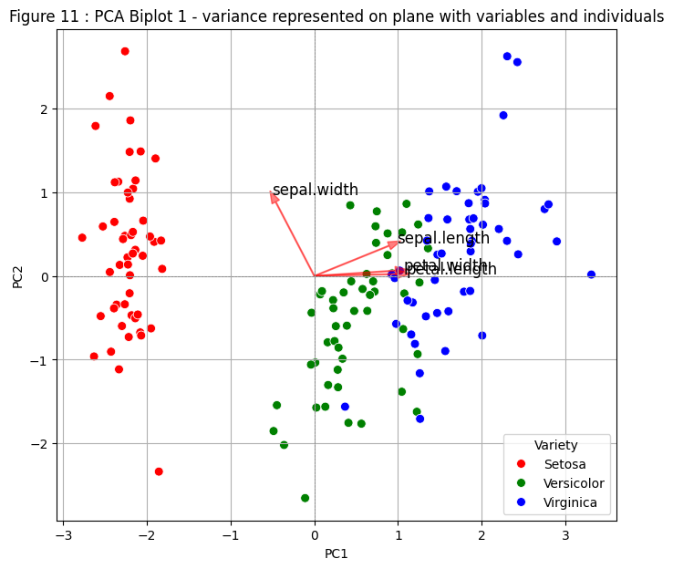

```python
# Create a biplot (version 1)
plt.figure(figsize=(10, 7))
scatter = sns.scatterplot(x=pca_df['PC1'], y=pca_df['PC2'], hue=pca_df['variety'], palette=colors, s=50)

# Add arrows for loadings (variables)
for i in range(loadings_df.shape[0]):
    plt.arrow(0, 0, loadings_df.iloc[i, 0], loadings_df.iloc[i, 1],
              color='red', alpha=0.5, width=0.01, head_width=0.1)
    plt.text(loadings_df.iloc[i, 0] * 1.1, loadings_df.iloc[i, 1] * 1.1,
             loadings_df.index[i], fontsize=12)

# Add labels and title
plt.axhline(0, color='grey', lw=0.5, ls='--')
plt.axvline(0, color='grey', lw=0.5, ls='--')
plt.title('Figure 11 : PCA Biplot 1 - variance represented on plane with variables and individuals')
plt.xlabel('PC1')
plt.ylabel('PC2')
plt.grid()
plt.gca().set_aspect('equal')
plt.legend(title='Variety')

plt.savefig('Figure11_PCA_Biplot1_variance_represented_on_plane_with_variables_and_individuals.png', dpi= 300)

plt.show()
```

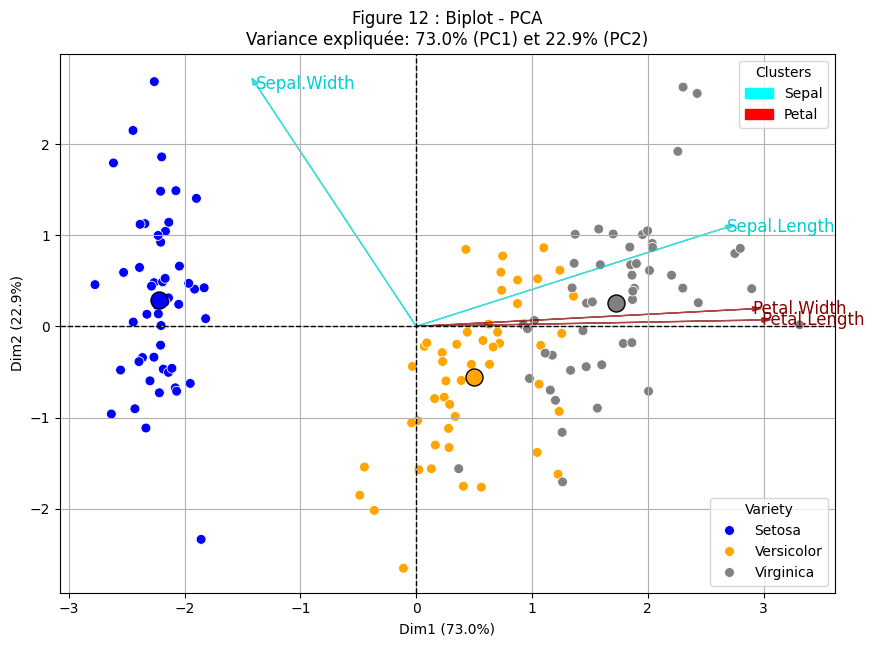

```python
## Create biplot with seaborn (version 2)

# Selecting required variables
features = iris_df[['sepal.length', 'sepal.width', 'petal.length', 'petal.width']]

# Create a color palette
palette_couleur = ['Blue', 'orange', 'gray']

# Standardizing features (centring and reducing)
scaled_features = StandardScaler().fit_transform(features)

# Applying PCA
pca = PCA(n_components=2)
principal_components = pca.fit_transform(scaled_features)

# Récupération des composantes principales
explained_variance = pca.explained_variance_ratio_

# Create a DataFrame from PCA results
pca_df = pd.DataFrame(data=principal_components, columns=['PC1', 'PC2'])
pca_df['variety'] = iris_df['variety']

# Facteur d'échelle pour maximiser la visibilité des vecteurs
scale_factor = 3

# Création du biplot
plt.figure(figsize=(10, 7))
scatter = sns.scatterplot(x=pca_df['PC1'], y=pca_df['PC2'], hue=pca_df['variety'], palette=palette_couleur, s=50)

# Ajout des flèches pour les vecteurs des variables
loadings = pca.components_.T * np.sqrt(pca.explained_variance_)

for i, name in enumerate(['Sepal.Length', 'Sepal.Width', 'Petal.Length', 'Petal.Width']):
    ncolor = 'DarkRed'
    if 'Sepal' in name:
        ncolor = 'DarkTurquoise'

    plt.arrow(0, 0, loadings[i, 0] * scale_factor, loadings[i, 1] * scale_factor, color=ncolor, alpha=0.7, head_width=0.05)
    plt.text(loadings[i, 0] * scale_factor, loadings[i, 1] * scale_factor, name, color=ncolor, fontsize=12, ha='left', va='center')

# Ajout de la légende pour les clusters de variables (Sepal/Petal)
sepal_patch = mpatches.Patch(color='cyan', label='Sepal')
petal_patch = mpatches.Patch(color='red', label='Petal')

# Ajouter la légende variety sans la remplacer
legend1 = plt.legend(handles=[sepal_patch, petal_patch], title="Clusters", loc="upper right")

# Ajouter la légende pour les variétés gérée par seaborn
scatter.legend(title='Variety', loc='lower right')

# Calcul des centroïdes pour chaque variété
centroids = pca_df.groupby('variety').mean()

# Tracé des centroïdes
for (variety, centroid), couleurc in zip(centroids.iterrows(), palette_couleur):
    plt.scatter(centroid['PC1'], centroid['PC2'], c=couleurc, s=150, marker='o', edgecolor='k')

# Ajout des titres et annotations
plt.axhline(0, color='black', linestyle='--', linewidth=1)
plt.axvline(0, color='black', linestyle='--', linewidth=1)
plt.title(f'Figure 12 : Biplot - PCA\nVariance expliquée: {explained_variance[0]*100:.1f}% (PC1) et {explained_variance[1]*100:.1f}% (PC2)')
plt.xlabel(f'Dim1 ({explained_variance[0]*100:.1f}%)')
plt.ylabel(f'Dim2 ({explained_variance[1]*100:.1f}%)')
plt.grid(True)

# Affichage des deux légendes
plt.gca().add_artist(legend1)

plt.savefig('Figure12_PCA_Biplot2.png', dpi= 300)

plt.show()
```

### Figure 12: Biplot - PCA (Variables and Individuals)

This figure presents a **biplot** combining the representation of:

- **Individuals** (each point corresponds to a sample, colored by Iris species: Setosa, Versicolor, Virginica),
- **Variables** (arrows showing the contribution of original features: Sepal Width, Sepal Length, Petal Width, and Petal Length).

#### Key observations:

- **Variance explained**:
  - The first principal component (**PC1**) explains **73.0%** of the total variance.
  - The second principal component (**PC2**) explains **22.9%**.
- **Total variance represented**:
  - Together, **PC1 and PC2 capture 95.9%** of the total variability in the data (73.0% + 22.9% = 95.9%).

#### Interpretation:

- **Individuals**:
  - **Setosa** samples (blue) form a distinct cluster on the left side of the plot.
  - **Versicolor** (orange) and **Virginica** (grey) samples are more spread but partially separable.
- **Variables**:
  - **Petal Length** and **Petal Width** vectors are strongly aligned with PC1, indicating that PC1 mainly reflects variations in petal size.
  - **Sepal Length** contributes moderately to PC1 and PC2.
  - **Sepal Width** points more vertically, suggesting it contributes more to PC2.

#### Overall:

- The biplot shows that most of the important information about both the individuals and variables is well captured in this two-dimensional plane.
- This visualization efficiently summarizes the structure of the data, revealing groupings of samples and relationships among variables.

```python
# Create a PCA model with 4 components
pca= PCA(n_components= 4)
pca_result = pca.fit_transform(features)

# Display the PCA variance
print(pca.explained_variance_)
print(pca.explained_variance_ratio_)
```

```
[4.22824171 0.24267075 0.0782095  0.02383509]
[0.92461872 0.05306648 0.01710261 0.00521218]
```

```python
# Display explained variance
explained_variance = pca.explained_variance_ratio_
print(f'Explained variance by PC1: {explained_variance[0]:.4f}')
print(f'Explained variance by PC2: {explained_variance[1]:.4f}')


print(f'Total variance explained: {np.sum(explained_variance):.4f}')
```

```
Explained variance by PC1: 0.9246
Explained variance by PC2: 0.0531
Total variance explained: 1.0000
```

```python
# Create a dataframe to summarize the variance
variance_df = pd.DataFrame({
    'Principal Component': [f'PC{i+1}' for i in range(len(pca.explained_variance_))],
    'Explained Variance': pca.explained_variance_,
    'Explained Variance Ratio': pca.explained_variance_ratio_
})

print(variance_df)
```

```
  Principal Component  Explained Variance  Explained Variance Ratio
0                 PC1            4.228242                  0.924619
1                 PC2            0.242671                  0.053066
2                 PC3            0.078210                  0.017103
3                 PC4            0.023835                  0.005212
```

```python
from sklearn.pipeline import make_pipeline
```

```python
# Set PCA to retain all components
pca = PCA(n_components=4)
pca.fit(features)  # features is iris dataset selected variables
```

```
PCA(n_components=4)
```

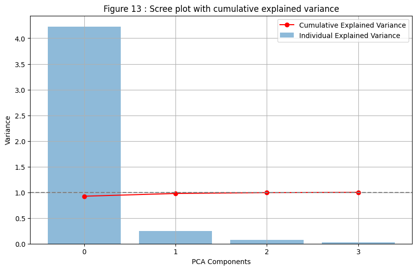

```python
# Create the scree plot for explained variance
scree = range(pca.n_components_)
explained_variance = pca.explained_variance_
cumulative_variance = np.cumsum(pca.explained_variance_ratio_)

plt.figure(figsize=(10, 6))

# Bar plot for individual explained variance
plt.bar(scree, explained_variance, alpha=0.5, label='Individual Explained Variance')
plt.xlabel('PCA Components')
plt.ylabel('Variance')
plt.xticks(scree)

# Line plot for cumulative explained variance
plt.plot(scree, cumulative_variance, marker='o', color='red', label='Cumulative Explained Variance')

# Add legend and title
plt.title('Figure 13 : Scree plot with cumulative explained variance')
plt.legend()
plt.grid()
plt.axhline(y=1, color='grey', linestyle='--')  # Optional line at y=1

plt.savefig('Figure13_Scree_plot_with_cumulative_explained_variance', dpi= 300)

plt.show()
```

### Figure 13: Scree plot with cumulative explained variance

This figure presents the **scree plot** for the Principal Component Analysis (PCA) of the Iris dataset.

- **Blue bars** represent the **individual explained variance** for each principal component.
- **Red line with points** represents the **cumulative explained variance**.

#### Conclusion:

- The scree plot clearly supports the choice to reduce the dimensionality of the dataset to **two principal components** without significant information loss.
- Components beyond PC2 do not contribute meaningfully to explaining variance and can be ignored in further analysis.

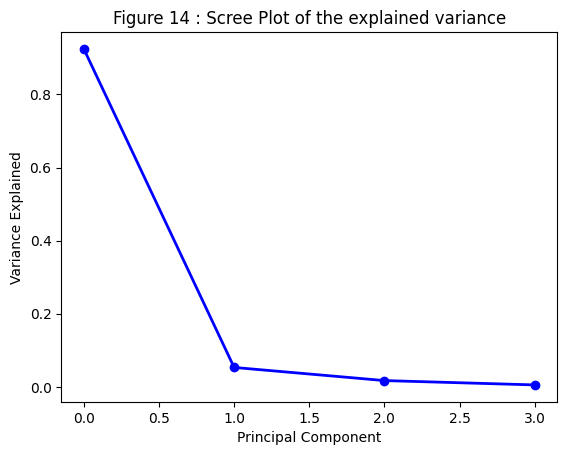

```python
# A different scree plot
plt.plot(scree, pca.explained_variance_ratio_, 'o-', linewidth=2, color='blue')
plt.title('Figure 14 : Scree Plot of the explained variance')
plt.xlabel('Principal Component')
plt.ylabel('Variance Explained')
plt.savefig('Figure14_variance_explained_scree_plot.png')
plt.show()
```

[ENG]

9. Produce a table showing the eigenvalues and % of variance explained for each component. What link seems to exist between the eigenvalues and the % of variance explained ?

[FR]

9. Produisez une table représentant pour chaque composantes les eigenvalues, et le % de variance expliquée, comme dans la Table 1 de l'énoncé. Quel lien semble unir les eigenvalues et le % de variance expliquée ?

```python
# Produce a summary table of Eigenvalues (variance explained) and proportions of simple and cumulative variances
eig = pd.DataFrame(
    {
        "Dimension" : ["Dim" + str(x + 1) for x in range(4)],
        "Eigen-values (Variance expliquée)" : pca.explained_variance_,
        "% variance expliquée" : np.round(pca.explained_variance_ratio_ * 100),
        "% cum. var. expliquée" : np.round(np.cumsum(pca.explained_variance_ratio_) * 100)
    }
)
eig
```

|  | Dimension | Eigen-values (Variance expliquée) | % variance expliquée | % cum. var. expliquée |
| --- | --- | --- | --- | --- |
| 0 | Dim1 | 4.228242 | 92.0 | 92.0 |
| 1 | Dim2 | 0.242671 | 5.0 | 98.0 |
| 2 | Dim3 | 0.078210 | 2.0 | 99.0 |
| 3 | Dim4 | 0.023835 | 1.0 | 100.0 |

### Table of Eigenvalues and Variance Explained

In Principal Component Analysis (PCA), each principal component has an associated **eigenvalue**.

- **Eigenvalues** indicate the amount of variance captured by each principal component.
- Larger eigenvalues correspond to components that capture more variability in the dataset.
- The **percentage of variance explained** by each component is calculated as the eigenvalue of the component divided by the sum of all eigenvalues.

### Interpretation

- **High Eigenvalue**: A high eigenvalue indicates that the component captures a significant portion of the total variability, meaning it contains valuable information about the dataset.
- **Variance Explained**: The percentage of variance explained normalizes this information, showing the relative importance of each principal component.
  - Example: If the first principal component accounts for 70% of the total variance, it is considered the most informative dimension.
- **Scree Plot**: A scree plot visualizes the eigenvalues (or the explained variance) against the component index.
  - The "elbow" point on the plot helps identify the number of components to retain, as additional components after this point add minimal explanatory power.

### Conclusion

- **Direct Link**: The eigenvalues directly determine the percentage of variance explained.
- **Key Insight**: Higher eigenvalues correspond to principal components that explain more variance, making them more significant for data representation.
- **Dimensionality Reduction**: Understanding this relationship is essential for deciding how many components to retain in PCA, balancing between simplification and information preservation.

[ENG]

10. Now use a table to represent the factor loading of the various variables on the principal components. For CP1, which variable has the highest factor loading ? What link can you make with the circle of correlations seen earlier?

[FR]

10. Représentez maintenant à travers une table la saturation (factor loading) des différentes variables sur les composantes principales. Quel est pour la CP1, la variable qui présente la saturation la plus forte ? Quel lien pouvez-vous effectuer avec le cercle des corrélations vu précédemment ?

```python
# Standardizing features (centring and reducing)
scaled_features = StandardScaler().fit_transform(features)
```

```python
# Re-run PCA with only two components
pca = PCA(n_components=2)
pca_transformed = pca.fit_transform(scaled_features)
```

```python
# Calculate loadings for the PCA
loadings = pca.components_.T * np.sqrt(pca.explained_variance_)
loadings_df = pd.DataFrame(loadings, index=['sepal.length', 'sepal.width', 'petal.length', 'petal.width'], columns=['PC1', 'PC2'])
```

```python
# Display loadings dataframe to identify the most important variable
print(loadings_df)
```

```
                   PC1       PC2
sepal.length  0.893151  0.362039
sepal.width  -0.461684  0.885673
petal.length  0.994877  0.023494
petal.width   0.968212  0.064214
```

```python
# Identify the variable with the highest loading on PC1
max_loading_variable = loadings_df['PC1'].idxmax()
max_loading_value = loadings_df['PC1'].max()

print(f"\nVariable with the highest loading on PC1: {max_loading_variable} with loading value: {max_loading_value:.4f}")

# Identify the relationship with the correlation circle
print(f"The variable '{max_loading_variable}' is likely to be closely aligned with PC1 in the correlation circle.")
```

```
Variable with the highest loading on PC1: petal.length with loading value: 0.9949
The variable 'petal.length' is likely to be closely aligned with PC1 in the correlation circle.
```

### Display of Loadings: Identifying the Most Important Variables

This table shows the **loadings** of each original variable on the first two principal components (**PC1** and **PC2**).

[ENG]

11. Create a table where, for each main component, you represent the variable with the highest saturation for a given principal component. There is a dedicated command in Python.

[FR]

11. Réalisez une table où pour chaque composante principale, en ligne, vous représentez la variable dont la saturation est la plus forte pour une composante principale donnée. Il existe une commande dédiée en Python.

```python
# Create a table with the variable that has the highest loading for each principal component
max_loadings_df = pd.DataFrame(index=[f'PC{i+1}' for i in range(loadings.shape[1])], columns=['Variable', 'Loading'])

for pc in max_loadings_df.index:
    max_loadings_df.loc[pc, 'Variable'] = loadings_df[pc].idxmax()  # Get the variable with max loading for each PC
    max_loadings_df.loc[pc, 'Loading'] = loadings_df[pc].max()      # Get the corresponding max loading value

# Display the saturation table
print("Saturation Table:")
print(max_loadings_df)
```

```
Saturation Table:
         Variable   Loading
PC1  petal.length  0.994877
PC2   sepal.width  0.885673
```

[ENG]

12. Now go back to the circle of correlations you made earlier. What link do you make between saturation of the variables and the orientation of the arrows representing vectors for each variable ?

[FR]

12. Reprenez maintenant le cercle des corrélations fait précédemment. Quel lien effectuez-vous entre saturation des variables et l’orientation des flèches représentant des vecteurs pour chaque variable ?

### Interpretation of the Correlation Circle: Link Between Saturation and Arrow Orientation

#### Orientation of Arrows

- If two arrows point in the **same direction** (small angle, close to 0°), the corresponding variables are **positively correlated**.
- If two arrows point in **opposite directions** (angle close to 180°), the variables are **negatively correlated**.
- If two arrows form an **angle close to 90°**, the variables are **uncorrelated** (no linear relationship).

#### Length of Arrows (Saturation)

- A **long arrow** represents a **highly saturated** variable on the principal components. It means the variable is **well represented** in the plane and contributes significantly to the variance explained.
- A **short arrow** indicates **low saturation**: the variable is poorly represented in the current projection and contributes little to the captured variance.

#### Link Between Saturation and Orientation

- The **saturation** (length) and the **orientation** of the arrows are directly related:
  - **Highly saturated variables** (long arrows) have meaningful orientations, illustrating strong positive or negative correlations with the principal components.
  - **Weakly saturated variables** (short arrows) are less correlated and are less informative in this projection.

[ENG]

13. Explain what exactly is meant by the quality of the PCA representation of a variable. Now show the correlation circle, but the colour of the arrow should depend on the quality of the PCA representation of the variables. You will use cos2 and then contributions. What is the main difference between these two metrics?

[FR]

13. Expliquez ce que signifie, au juste, la qualité de la représentation d’une variable par une ACP. Représentez maintenant le cercle des corrélations, mais la couleur de la fléche doit dépendre de la qualité de la représentation des variables par l’ACP. Vous utiliserez les cos2, puis les contributions. Quelle est la principale différence entre ces deux métriques ?

### Quality of the Representation of a Variable by PCA

The **quality of the representation** of a variable in PCA is measured by the **cos²** (squared cosine) of the angle between the variable vector and the principal axes.

- **cos²** is computed for each axis individually.
- It measures how much of a variable’s variance is captured by the projection onto a particular axis or plane.
- A **high cos² value** (close to 1) indicates that the axis explains most of the variability of the variable.
- A **low cos² value** suggests that the variable is poorly represented on that axis and that other axes may be needed to better understand its behavior.

In summary:

> The closer a variable lies to the principal axes in the projection, the better it is represented (higher cos² value).

### cos² vs Contribution

- **cos² (Squared Cosine)**:
  - Measures the **quality of the projection** of a variable onto a given axis.
  - Answers: *"How well does this axis represent this variable?"*
- **Contribution**:
  - Measures how much a variable **contributes to the formation** of a given axis.
  - Answers: *"How important is this variable in creating the axis?"*

### Main Difference

| Metric | Focus | Question Answered |
| --- | --- | --- |
| **cos²** | Quality of representation | How well is the variable projected on the axis? |
| **Contribution** | Importance in axis construction | How much does the variable contribute to forming the axis? |

### Why Study the Quality of Representation?

- Good quality of representation (high cos²) is necessary to interpret the positions of individuals or the relationships between variables reliably.
- If individuals or variables are **poorly projected**, their proximity on the plane may be misleading:
  - They might appear close on the 2D plot but actually be far apart in the full-dimensional space.
- Studying **contributions** is also important:
  - It reveals whether certain axes are mainly influenced by a few specific variables, helping to better interpret the axes' meaning.

### Visualization

- The **correlation circle** can be enhanced by coloring the arrows based on **cos²** values to show the quality of variable projections.
- Alternatively, coloring based on **contributions** highlights which variables were most influential in forming each axis.

```python
from matplotlib.colors import Normalize
import matplotlib.cm as cm
```

```python
# Calculating cos² (quality of representation) for PC1 and PC2
explained_variance = pca.explained_variance_ratio_
cos2 = (pca.components_**2) / np.sum(pca.components_**2, axis=0)
total_cos2= np.sum(cos2[:2, :], axis=0)  # Sum for PC1 and PC2
```

```python
# Create a cos2 table for better readability
cos2_df = pd.DataFrame(cos2.T, index=iris_df.columns[:-1], columns=[f"PC{i+1}" for i in range(pca.n_components_)])

cos2_df
```

|  | PC1 | PC2 |
| --- | --- | --- |
| sepal.length | 0.655894 | 0.344106 |
| sepal.width | 0.078428 | 0.921572 |
| petal.length | 0.998223 | 0.001777 |
| petal.width | 0.986150 | 0.013850 |

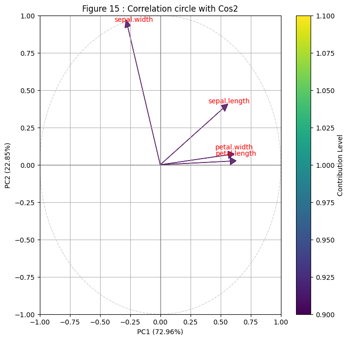

```python
# Assuming cos2_df and pca.components_ are already defined and that iris_df has the feature names
# Normalize the contributions to use in color mapping
cmap = cm.viridis  # Choose a colormap
total_cos2= np.sum(cos2[:2, :], axis=0)  # Sum for PC1 and PC2
norm = Normalize(vmin=np.min(total_cos2), vmax=np.max(total_cos2))
colors = cmap(norm(total_cos2))

# Plot the correlation circle with contributions
plt.figure(figsize=(8, 8))
for i, feature in enumerate(iris_df.columns[:-1]):
    plt.arrow(0, 0, pca.components_[0, i], pca.components_[1, i],
              color=colors[i], alpha=0.8, head_width=0.05, head_length=0.05)
    plt.text(pca.components_[0, i] + 0.05, pca.components_[1, i] + 0.05, feature,
             color='red', ha='center', va='center')

# Draw the correlation circle
circle = plt.Circle((0, 0), 1, color='lightgrey', fill=False, linestyle='--', linewidth=1)
plt.gca().add_artist(circle)

# Properly link the ScalarMappable object to the color bar
sm = plt.cm.ScalarMappable(cmap=cmap, norm=norm)
sm.set_array([])  # We set an empty array to avoid issues with the color bar
cbar = plt.colorbar(sm, ax=plt.gca())  # Explicitly set the axes for the color bar
cbar.set_label('Contribution Level')

# Set limits, labels, and titles
plt.xlim([-1, 1])
plt.ylim([-1, 1])
plt.xlabel(f"PC1 ({explained_variance[0]*100:.2f}%)")
plt.ylabel(f"PC2 ({explained_variance[1]*100:.2f}%)")
plt.grid()
plt.title('Figure 15 : Correlation circle with Cos2')
plt.axhline(0, color='grey', lw=1)
plt.axvline(0, color='grey', lw=1)

plt.savefig('Figure15_correlation_circle_with_Cos2', dpi= 300)

plt.show()
```

### Figure 15: Correlation Circle with Cos² Coloring

This figure displays the **correlation circle** for the variables of the Iris dataset, with arrows colored based on their **cos² values**.

```python
# Calculating contributions for PC1 and PC2
explained_variance = pca.explained_variance_ratio_
contributions = np.square(pca.components_) / np.sum(np.square(pca.components_), axis=1, keepdims=True)
total_contributions = np.sum(contributions[:2, :], axis=0)  # Sum for PC1 and PC2
```

```python
# Create a contribution table for better readability
contributions_df = pd.DataFrame(contributions.T, index=iris_df.columns[:-1], columns=[f"PC{i+1}" for i in range(pca.n_components_)])

contributions_df
```

|  | PC1 | PC2 |
| --- | --- | --- |
| sepal.length | 0.271510 | 0.142444 |
| sepal.width | 0.072548 | 0.852475 |
| petal.length | 0.336879 | 0.000600 |
| petal.width | 0.319063 | 0.004481 |

### Contribution Table: Interpretation in Principal Component Analysis (PCA)

This table, called the **contribution table**, represents the contributions of the original features (**sepal.length**, **sepal.width**, **petal.length**, **petal.width**) to each principal component (**PC1**, **PC2**) in a Principal Component Analysis (PCA).

### What Each Element Represents

- Each value indicates how much a specific feature contributes to the variance captured by a particular principal component.
- **Example**:
  - The contribution of **sepal.length** to PC1 is **0.2715**.
  - The contribution of **petal.length** to PC2 is **0.0006**.
- A **higher contribution value** means the feature has a stronger influence on the corresponding principal component.

### Row and Column Interpretation

- **Rows**: Represent the original features from the dataset.
- **Columns**: Represent the principal components (PC1, PC2, etc.).
  - Each principal component is a **linear combination** of the original features, optimized to capture maximum variance.

### Insights from the Table

#### PC1

- **Petal length** (0.3369) and **petal width** (0.3191) are the dominant contributors.
- **Interpretation**: PC1 mainly captures variability related to petal dimensions.

#### PC2

- **Sepal width** (0.8525) overwhelmingly dominates the second principal component.
- **Interpretation**: PC2 primarily captures variability associated with sepal width.

#### Minor Contributions

- **Petal length** and **petal width** contribute very little to PC2 (only 0.0006 and 0.0045 respectively), indicating they have minimal influence on this axis.

### Practical Use of the Contribution Table

#### Feature Importance

- Identifies which features are most influential for each principal component.
  - For PC1, focus should be on **petal.length** and **petal.width**.
  - For PC2, **sepal.width** is the key feature.

#### Dimensionality Reduction

- Helps guide decisions about keeping or discarding principal components:
  - If only PC1 and PC2 explain a large proportion of the variance, it is efficient to work with just these two PCs instead of all original features.
  - Variables with low contributions to all important PCs can be considered less relevant for further interpretation.

```python
# Extracts the principal axes in terms of the original variables, to understand and visualize PCA results
pca.components_[0: 2]
```

```
array([[ 0.52106591, -0.26934744,  0.5804131 ,  0.56485654],
       [ 0.37741762,  0.92329566,  0.02449161,  0.06694199]])
```

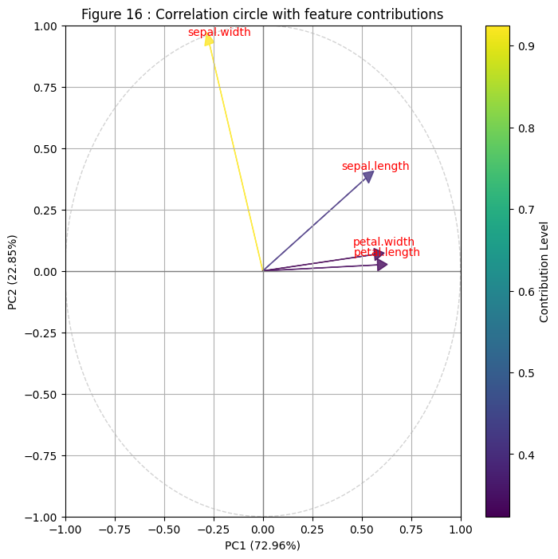

```python
# Assuming contributions_df and pca.components_ are already defined and that iris_df has the feature names
# Normalize the contributions to use in color mapping
cmap = cm.viridis  # Choose a colormap
total_contributions = np.sum(contributions[:2, :], axis=0)  # Sum for PC1 and PC2
norm = Normalize(vmin=np.min(total_contributions), vmax=np.max(total_contributions))
colors = cmap(norm(total_contributions))

# Plot the correlation circle with contributions
plt.figure(figsize=(8, 8))
for i, feature in enumerate(iris_df.columns[:-1]):
    plt.arrow(0, 0, pca.components_[0, i], pca.components_[1, i],
              color=colors[i], alpha=0.8, head_width=0.05, head_length=0.05)
    plt.text(pca.components_[0, i] + 0.05, pca.components_[1, i] + 0.05, feature,
             color='red', ha='center', va='center')

# Draw the correlation circle
circle = plt.Circle((0, 0), 1, color='lightgrey', fill=False, linestyle='--', linewidth=1)
plt.gca().add_artist(circle)

# Properly link the ScalarMappable object to the color bar
sm = plt.cm.ScalarMappable(cmap=cmap, norm=norm)
sm.set_array([])  # We set an empty array to avoid issues with the color bar
cbar = plt.colorbar(sm, ax=plt.gca())  # Explicitly set the axes for the color bar
cbar.set_label('Contribution Level')

# Set limits, labels, and titles
plt.xlim([-1, 1])
plt.ylim([-1, 1])
plt.xlabel(f"PC1 ({explained_variance[0]*100:.2f}%)")
plt.ylabel(f"PC2 ({explained_variance[1]*100:.2f}%)")
plt.grid()
plt.title('Figure 16 : Correlation circle with feature contributions')
plt.axhline(0, color='grey', lw=1)
plt.axvline(0, color='grey', lw=1)

plt.savefig('Figure16_correlation_circle_with_feature_contributions.png', dpi= 300)

plt.show()
```

### Figure 16: Correlation Circle Colored by Feature Contributions

This figure shows the **correlation circle** for the variables of the Iris dataset, where the arrows are colored based on the **contribution** of each variable to the first two principal components (PC1 and PC2).

#### Conclusion:

- This visualization highlights which variables are the most influential in constructing the principal components.
- **Sepal width** plays a dominant role in defining PC2, while **petal dimensions** (length and width) primarily shape PC1.
- Understanding contributions helps focus analysis on the most impactful features for explaining the dataset's variability.

[ENG]

14. Repeat the previous step, but this time representing only the individuals on the factorial plane. In the same way, the colour of the individuals will depend on the quality of their PCA representation.

[FR]

14. Répétez l’étape précédentes, mais en représentant cette fois uniquement les individus sur le plan factoriel. De la même manière, la couleur des individus devra dépendre de la qualité de leur représentation par l’ACP.

```python
# Apply PCA
pca = PCA(n_components=2)
pca_scores = pca.fit_transform(scaled_features)  # Project individuals onto the PCA space
```

```python
# Calculate cos² (quality of representation) for each individual
cos2_individuals = np.sum(np.square(pca_scores), axis=1) / np.sum(np.square(pca_scores), axis=1)
```

```python
# Assuming pca_scores and cos2_individuals are already defined
# Normalize cos² values for color mapping
cmap = cm.viridis  # Choose a colormap
norm = Normalize(vmin=np.min(cos2_individuals), vmax=np.max(cos2_individuals))
colors = cmap(norm(cos2_individuals))
```

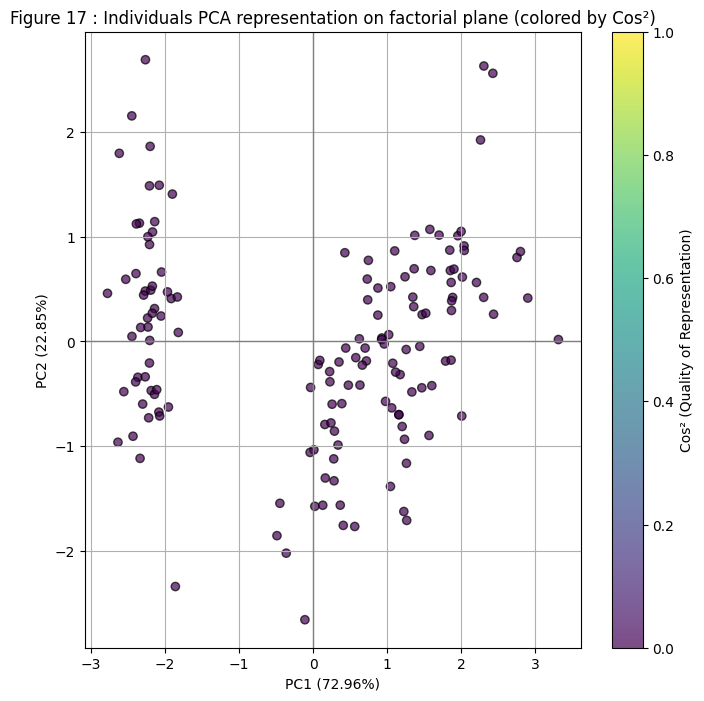

```python
# Plot the individuals on the factorial plane with colors based on cos²
plt.figure(figsize=(8, 8))
scatter = plt.scatter(pca_scores[:, 0], pca_scores[:, 1], c=colors, alpha=0.7, edgecolor='k')

# Plot axis lines and labels
plt.axhline(0, color='grey', lw=1)
plt.axvline(0, color='grey', lw=1)
plt.xlabel(f"PC1 ({pca.explained_variance_ratio_[0]*100:.2f}%)")
plt.ylabel(f"PC2 ({pca.explained_variance_ratio_[1]*100:.2f}%)")
plt.title('Figure 17 : Individuals PCA representation on factorial plane (colored by Cos²)')
plt.grid(True)

# Add a color bar to indicate the cos² values
cbar = plt.colorbar(scatter)
cbar.set_label('Cos² (Quality of Representation)')

plt.savefig('Figure17_individuals_PCA_representation_on_factorial_plane_(colored_by_Cos²).png', dpi= 300)

plt.show()
```

## Cos² Values and Color Interpretation in PCA

### Cos² Values

- **Cos² (cosine squared)** values measure how well each individual (observation) is represented by the principal components.
- For each individual, the cos² values for PC1 and PC2 indicate how much of the individual’s total variance is explained by these two components.
- A **high cos² value** means the individual is **well represented** by the components.
- A **low cos² value** indicates the individual is **poorly represented** and that more components may be needed to better explain its variability.

### Color Interpretation

- **Bright Colors**: Individuals with high cos² values; most of their variance is captured by the first two principal components.
- **Dark Colors**: Individuals with low cos² values; a significant part of their variance lies outside the PC1-PC2 plane.

### Example of Interpretation

| Individual | Cos² PC1 | Cos² PC2 | Interpretation | Color |
| --- | --- | --- | --- | --- |
| Ind_1 | 0.85 | 0.10 | Well represented by PC1 | Bright Yellow |
| Ind_2 | 0.40 | 0.45 | Moderately represented by PC1 and PC2 | Green |
| Ind_3 | 0.15 | 0.05 | Poorly represented by PC1 and PC2 | Dark Purple |

- **Ind_1**: High cos² → strong representation → bright color.
- **Ind_3**: Low cos² → weak representation → dark color.

### Summary

[ENG]

15. Produce a table representing the contribution of individuals to the first two axes of the PCA. What exactly does this contribution represent ?

[FR]

15. Produisez une table représentant la contribution des individus aux deux premiers axes de l’ACP. Que représente au juste cette contribution ?

```python
# Assuming pca and pca_scores have been calculated (pca_scores contains the projected individuals)
# pca_scores contains the individuals projected onto the PCA plane
# pca.components_ is used for the PCA component loadings

# Calculate squared scores for each individual
squared_scores = np.square(pca_scores)

# Sum of squared scores for each individual
total_squared_scores = np.sum(squared_scores, axis=1, keepdims=True)

# Calculate individual contributions (squared scores normalized by the sum of squared scores for each individual)
contributions_individuals = squared_scores / total_squared_scores

# Create a DataFrame for the contributions to PC1 and PC2
contributions_individuals_df = pd.DataFrame(contributions_individuals, columns=["Contribution PC1", "Contribution PC2"])

contributions_individuals_df
```

|  | Contribution PC1 | Contribution PC2 |
| --- | --- | --- |
| 0 | 0.957005 | 0.042995 |
| 1 | 0.905022 | 0.094978 |
| 2 | 0.979514 | 0.020486 |
| 3 | 0.936769 | 0.063231 |
| 4 | 0.931743 | 0.068257 |
| ... | ... | ... |
| 145 | 0.958958 | 0.041042 |
| 146 | 0.752750 | 0.247250 |
| 147 | 0.969662 | 0.030338 |
| 148 | 0.648238 | 0.351762 |
| 149 | 0.999359 | 0.000641 |

150 rows × 2 columns

### Contribution Table of Individuals to the First Two Principal Components

This table displays the **contributions of individuals** to the first two principal components (**PC1** and **PC2**) in the PCA.

### Conclusion

[ENG]

18. Recall how the k-means algorithm works, emphasising the difference between the expectation stage and the maximisation stage. Describe the trajectory followed by the various centroids over the iterations of this algorithm.

[FR]

18. Rappelez le fonctionnement de l’algorithme k-means, en insistant sur la différence entre l’étape dite d’expectation, et celle de maximisation. Décrivez la trajectoire que suivent, avec cet algorithme, les différents centroïdes au fil des itérations.

## K-Means Algorithm and the Expectation-Maximization Process

### K-Means Overview

- **K-means** is a **centroid-based clustering algorithm**. It assigns each data point to the nearest centroid to form clusters, aiming to partition the dataset into **K groups** based on similarity.
- The objective of clustering is to divide the dataset into groups where points within a group are similar to each other and different from points in other groups.
- It is an **unsupervised learning** method, requiring the user to predefine the number of clusters **K**. This value is often chosen arbitrarily at the start, but optimization methods like the **elbow method** or **silhouette score** can help determine a more appropriate K.

#### Example:

- If K = 3, the algorithm initializes three centroids (A, B, C) placed randomly.
- Each data point is assigned to the nearest centroid based on a distance metric (usually Euclidean distance).
- The process iterates: recalculating centroids and reassigning points until convergence.

### Expectation-Maximization Structure in K-Means

K-Means can be viewed as a simplified form of the **Expectation-Maximization (EM)** framework:

- **Expectation (E) step**:
  - Assign each data point to the nearest centroid (based on current centroid positions).
  - This step estimates the "membership" of each point to a cluster (hard assignment in K-means).
- **Maximization (M) step**:
  - Update the position of each centroid as the mean of all points assigned to that cluster.
  - This step optimizes the centroid locations based on current memberships.

This alternating structure ensures that with each iteration, the clustering improves (i.e., intra-cluster distances decrease).

### Difference Between K-Means and True EM Algorithm

- In **K-means**, the cluster shapes are constrained to **spherical** forms due to reliance on Euclidean distance.
- In **Expectation-Maximization** for **Gaussian Mixture Models (GMM)**:
  - Clusters can take **elliptical** or **complex shapes**.
  - EM handles **soft assignments** (probabilistic memberships), rather than hard cluster memberships.
  - EM updates **covariance matrices**, allowing for more flexible modeling of the data structure.

Thus, **EM** is more powerful than **K-means** for capturing complex sub-populations in data.

### Behavior of Centroids During K-Means Iterations

1. **Initialization**:
   - Centroids are initialized (randomly or via smarter methods like **K-means++**).
   - Initial centroids may be far from the true cluster centers.
2. **Point Assignment**:
   - Each point is assigned to its closest centroid, creating initial clusters.
3. **Centroid Update**:
   - Centroids are updated by computing the mean position of all points in the cluster.
   - Early iterations usually see **large movements** of centroids toward the true cluster centers.
4. **Convergence**:
   - The process repeats until centroid positions **stabilize** (changes fall below a predefined threshold).
   - Movement becomes progressively smaller with each iteration, particularly after initial major adjustments.

#### Note:

- Running K-means for multiple K values and plotting the **sum of within-cluster distances** can help identify an optimal K through the **elbow method**.

### Conclusion

- K-Means is a fast and efficient clustering method suitable for simple, well-separated clusters.
- Viewing K-Means within the EM framework highlights the importance of **separating the "assignment" and "update" stages** clearly.
- Understanding centroid trajectories helps in appreciating the convergence behavior and the importance of proper centroid initialization.

[ENG]

19. Apply the kmeans algorithm to cluster the different flowers identified in the dataset, then display the different individuals in the same plane as the PCA, with one colour per cluster. You will therefore need to take as input a defined number of principal components, and not the original variables in the dataset. You will start with k=3. Describe the characteristics of these three clusters, in terms of the averages of the quantitative variables, and the proportions of the different species represented.

[FR]

19. Appliquez l’algorithme de kmeans pour réaliser un clustering des différentes fleurs recensées dans le jeu de données, puis affichez dans le même plan que celui de l’ACP les différents individus, avec une couleur par cluster. Vous devrez donc prendre en entrée un nombre défini de composantes principales, et non les variables originelles du jeu de données. Vous commencerez avec k=3. Décrivez les caractéristiques de ces trois clusters, en termes de moyennes de variables quantitatives, et de proportions des différentes espèces représentées.

```python
from sklearn.cluster import KMeans
from sklearn.preprocessing import StandardScaler
```

```python
print(iris_df["variety"].head())
```

```
0    Setosa
1    Setosa
2    Setosa
3    Setosa
4    Setosa
Name: variety, dtype: category
Categories (3, object): ['Setosa', 'Versicolor', 'Virginica']
```

```python
iris_df.head()
```

|  | sepal.length | sepal.width | petal.length | petal.width | variety |
| --- | --- | --- | --- | --- | --- |
| 0 | 5.1 | 3.5 | 1.4 | 0.2 | Setosa |
| 1 | 4.9 | 3.0 | 1.4 | 0.2 | Setosa |
| 2 | 4.7 | 3.2 | 1.3 | 0.2 | Setosa |
| 3 | 4.6 | 3.1 | 1.5 | 0.2 | Setosa |
| 4 | 5.0 | 3.6 | 1.4 | 0.2 | Setosa |

```python
# Create a new dataframe by deleting the ‘variety’ column containing the categories
iris_df2 = iris_df.drop("variety", axis=1)
```

```python
# Standardizing the dataframe (centring and reducing)
scaler= StandardScaler()
iris_df2_scaled= scaler.fit_transform(iris_df2)

# Applying PCA to reduce dimensionality to four main components
pca19= PCA(n_components= 4)
pca19_ok= pca19.fit_transform(iris_df2_scaled)
```

```python
# Apply the K-Means algorithm with 3 clusters and k-means++.
model = KMeans(n_clusters=3, init='k-means++', n_init=20,random_state=42)
labels = model.fit_predict(pca19_ok)  # Adapt the KMeans model to the data and obtain the clusters
```

```python
# Create a DataFrame combining the labels obtained with the original species
new_iris_df = pd.DataFrame({'PC1': pca19_ok[:, 0], 'PC2': pca19_ok[:, 1], 'Cluster': labels, 'Species': iris_df['variety']})

new_iris_df.head()
```

|  | PC1 | PC2 | Cluster | Species |
| --- | --- | --- | --- | --- |
| 0 | -2.264703 | 0.480027 | 1 | Setosa |
| 1 | -2.080961 | -0.674134 | 1 | Setosa |
| 2 | -2.364229 | -0.341908 | 1 | Setosa |
| 3 | -2.299384 | -0.597395 | 1 | Setosa |
| 4 | -2.389842 | 0.646835 | 1 | Setosa |

```python
# Create a mapping between clusters and the most frequent species in each cluster
cluster_to_species = new_iris_df.groupby('Cluster')['Species'].agg(lambda x: x.mode()[0]).to_dict()
cluster_to_species
```

```
{0: 'Versicolor', 1: 'Setosa', 2: 'Virginica'}
```

```python
# Add a new column using species names instead of cluster labels
new_iris_df['Cluster_Name'] = new_iris_df['Cluster'].map(cluster_to_species)

new_iris_df.head()
```

|  | PC1 | PC2 | Cluster | Species | Cluster_Name |
| --- | --- | --- | --- | --- | --- |
| 0 | -2.264703 | 0.480027 | 1 | Setosa | Setosa |
| 1 | -2.080961 | -0.674134 | 1 | Setosa | Setosa |
| 2 | -2.364229 | -0.341908 | 1 | Setosa | Setosa |
| 3 | -2.299384 | -0.597395 | 1 | Setosa | Setosa |
| 4 | -2.389842 | 0.646835 | 1 | Setosa | Setosa |

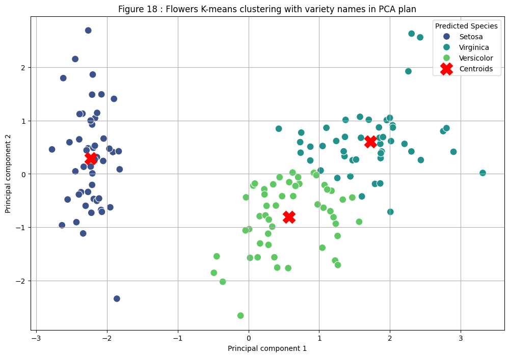

```python
# Plot clusters and centroids in the 2D plane using the two principal components of PCA
plt.figure(figsize=(12, 8))
sns.scatterplot(data=new_iris_df, x='PC1', y='PC2', hue='Cluster_Name', palette='viridis', s=100, legend='full')
plt.scatter(model.cluster_centers_[:, 0], model.cluster_centers_[:, 1], s=300, c='red', marker='X', label='Centroids')

plt.title('Figure 18 : Flowers K-means clustering with variety names in PCA plan')
plt.xlabel('Principal component 1')
plt.ylabel('Principal component 2')
plt.legend(title='Predicted Species')
plt.grid(True)
plt.savefig('Figure18_flowers_k-means_clustering_with_variety_names_in_PCA_plan.png', dpi= 300)
plt.show()
```

### Figure 18: K-means Clustering of Iris Flower Varieties in PCA Space

This plot visualizes the result of applying K-means clustering (with *k=3*) on the Iris dataset, projected onto the first two principal components obtained via PCA. Each point represents a flower sample, colored according to the predicted cluster label. The actual variety names (`Setosa`, `Versicolor`, and `Virginica`) are used for labeling the clusters based on their majority class composition.

```python
# Analyse species distribution by cluster
species_distribution = new_iris_df.groupby('Cluster')['Species'].value_counts(normalize=True).unstack().round(2)
print("\nSpecies distribution within each cluster:")
print(species_distribution)
```

```
Species distribution within each cluster:
Species  Setosa  Versicolor  Virginica
Cluster
0           0.0        0.74       0.26
1           1.0        0.00       0.00
2           0.0        0.23       0.77
```

### Evaluation of K-Means Clustering by Species

The following clustering results are based on the proportion of actual species found within each cluster:

**Conclusion**:

- The KMeans algorithm successfully and cleanly separates the **Setosa** species, which is likely due to its distinctive feature profile.
- **Versicolor** and **Virginica** are not well-separated by the algorithm, as they share overlapping clusters. This result reflects the known challenge of distinguishing these two species based on unsupervised methods like KMeans.

```python
import skimpy
```

```python
# Merge the new_iris_df dataset with the iris_df dataset to add the sepal and petal variables
new_iris_df_2 = pd.merge(new_iris_df, iris_df, left_index=True, right_index=True)
new_iris_df_2.head()
```

|  | PC1 | PC2 | Cluster | Species | Cluster_Name | sepal.length | sepal.width | petal.length | petal.width | variety |
| --- | --- | --- | --- | --- | --- | --- | --- | --- | --- | --- |
| 0 | -2.264703 | 0.480027 | 1 | Setosa | Setosa | 5.1 | 3.5 | 1.4 | 0.2 | Setosa |
| 1 | -2.080961 | -0.674134 | 1 | Setosa | Setosa | 4.9 | 3.0 | 1.4 | 0.2 | Setosa |
| 2 | -2.364229 | -0.341908 | 1 | Setosa | Setosa | 4.7 | 3.2 | 1.3 | 0.2 | Setosa |
| 3 | -2.299384 | -0.597395 | 1 | Setosa | Setosa | 4.6 | 3.1 | 1.5 | 0.2 | Setosa |
| 4 | -2.389842 | 0.646835 | 1 | Setosa | Setosa | 5.0 | 3.6 | 1.4 | 0.2 | Setosa |

```python
# Calculate the average of variables per cluster
variable_means= new_iris_df_2.groupby(["Cluster", "Cluster_Name"])[["sepal.length", "petal.length", "sepal.width"]].mean().round(2)

variable_means
```

| Cluster | Cluster_Name | sepal.length | petal.length | sepal.width |
| --- | --- | --- | --- | --- |
| 0 | Versicolor | 5.80 | 4.37 | 2.67 |
| 1 | Setosa | 5.01 | 1.46 | 3.43 |
| 2 | Virginica | 6.78 | 5.51 | 3.10 |

### Cluster-wise Feature Averages

The table above displays the average sepal length, petal length, and sepal width for each cluster, annotated with their corresponding dominant species:

- **Cluster Virginica**:
  - Sepal Length: **6.78 cm**
  - Petal Length: **5.51 cm**
  - Sepal Width: **3.10 cm**
  - This cluster has the highest values for both sepal and petal length, which aligns with known characteristics of the *Virginica* species.
- **Cluster Versicolor**:
  - Sepal Length: **5.80 cm**
  - Petal Length: **4.37 cm**
  - Sepal Width: **2.67 cm**
  - Intermediate values reflect the expected measurements for *Versicolor*, although there's partial confusion with Virginica in clustering.
- **Cluster Setosa**:
  - Sepal Length: **5.01 cm**
  - Petal Length: **1.46 cm**
  - Sepal Width: **3.43 cm**
  - The smallest petal length and relatively wider sepal width distinctly characterize the *Setosa* species, consistent with its clean separation in clustering.

**Conclusion**:  
These feature averages confirm that **Setosa** is easily distinguishable due to its unique petal and sepal dimensions, while **Versicolor** and **Virginica** exhibit overlapping ranges, which may explain the clustering confusion between them.

[ENG]

20. Use a scree plot to explore the evolution of the intracluster variance, and apply different techniques to determine the optimal number of clusters to retain. Explain the logic behind the different techniques used.

[FR]

20. Explorez grâce à un scree plot l’évolution de la variance intracluster, et appliquez différentes techniques pour déterminer le nombre optimal de clusters a retenir. Expliquez la logique sous-jacente aux différentes techniques mobilisées.

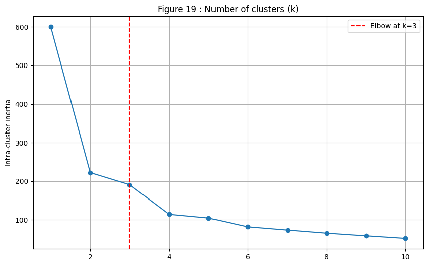

```python
# Calculate inertia for different values of k
inertias = []
K_range = range(1, 11)
for k in K_range:
    kmeans = KMeans(n_clusters=k)
    kmeans.fit(iris_df2_scaled)
    inertias.append(kmeans.inertia_)

# Scree plot
plt.figure(figsize=(10, 6))
plt.plot(K_range, inertias, marker='o')
plt.title('Figure 19 : Number of clusters (k)')
plt.ylabel('Intra-cluster inertia')
plt.grid(True)
plt.axvline(x=3, color='red', linestyle='--', label='Elbow at k=3')
plt.legend()
plt.savefig('Figure19_inertia_evolution_based_on_clusters_number', dpi=300)
plt.show()
```

### Figure 19: Determining the Optimal Number of Clusters Using the Elbow Method

This figure presents the **Elbow Plot**, which visualizes the relationship between the number of clusters (`k`) and the **intra-cluster inertia** (a measure of cluster compactness).

```python
from sklearn.metrics import silhouette_samples, silhouette_score
```

```python
# Range of cluster numbers to evaluate
cluster_range = range(2, 11)  # Silhouette score is not defined for k=1
silhouette_scores = []  # List to store silhouette scores for each number of clusters

# Calculate the silhouette score for each k
for k in cluster_range:
    kmeans = KMeans(n_clusters=k, random_state=42)
    cluster_labels = kmeans.fit_predict(iris_df2_scaled)
    score = silhouette_score(iris_df2_scaled, cluster_labels)
    silhouette_scores.append(score)

    # Debugging statements to track the loop progress
    print(f"Number of clusters: {k}, Silhouette Score: {score}")

# Debugging step to verify list lengths
print(f"Length of cluster_range: {len(cluster_range)}")  # Should be 9
print(f"Length of silhouette_scores: {len(silhouette_scores)}")  # Should also be 9
```

```
Number of clusters: 2, Silhouette Score: 0.5817500491982808
Number of clusters: 3, Silhouette Score: 0.4798814508199818
Number of clusters: 4, Silhouette Score: 0.3850454053045392
Number of clusters: 5, Silhouette Score: 0.34503345350274617
Number of clusters: 6, Silhouette Score: 0.33394323040061763
Number of clusters: 7, Silhouette Score: 0.2664290993719981
Number of clusters: 8, Silhouette Score: 0.34162906041313373
Number of clusters: 9, Silhouette Score: 0.3243991438983545
Number of clusters: 10, Silhouette Score: 0.33540615043919825
Length of cluster_range: 9
Length of silhouette_scores: 9
```

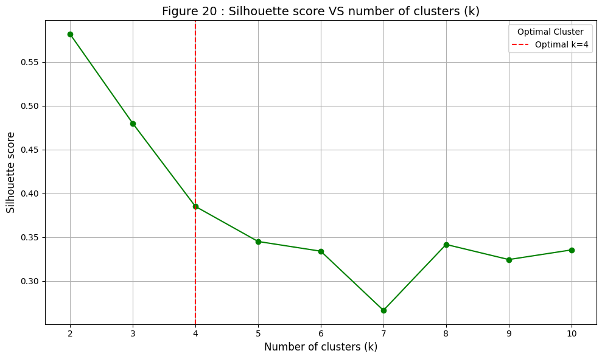

```python
# Plotting the silhouette scores for each k if the dimensions match
if len(cluster_range) == len(silhouette_scores):
    plt.figure(figsize=(10, 6))
    plt.plot(cluster_range, silhouette_scores, marker='o', color='green', linestyle='-')
    plt.title('Figure 20 : Silhouette score VS number of clusters (k)', fontsize=14)
    plt.xlabel('Number of clusters (k)', fontsize=12)
    plt.ylabel('Silhouette score', fontsize=12)
    plt.axvline(x=4, color='red', linestyle='--', label='Optimal k=4', linewidth=1.5)
    plt.grid(True)
    plt.legend(title='Optimal Cluster', loc='best')
    plt.tight_layout()
    plt.savefig('Figure20_silhouette_score_vs_number_of_clusters_(k).png', dpi= 300)
    plt.show()
else:
    print("Error: The lengths of cluster_range and silhouette_scores do not match!")
```

### Figure 20: Silhouette Score vs. Number of Clusters (k)

This plot evaluates clustering quality for different values of `k` using the **silhouette score**, which measures how similar an object is to its own cluster compared to others (range: -1 to 1).

- The **highest silhouette score** occurs at **k = 2**, indicating well-separated and compact clusters.
- However, **k = 3 and k = 4** also show relatively good scores, suggesting viable alternative clustering solutions.
- The red dashed line highlights **k = 4** as the selected optimal cluster number for further analysis in this context.

**Interpretation**:

- Although k=2 gives the best silhouette score, it likely merges Versicolor and Virginica.
- **k=3 aligns with the known species**, but **k=4 might capture sub-structure**, such as an internal split within Versicolor or Virginica.
- The drop after k=4 shows diminishing returns and poorer separation for higher values of `k`.

**Conclusion**:

- Choosing **k = 4** offers a compromise between maintaining a reasonable silhouette score and discovering additional structure beyond the three known classes.

```python
cluster_range = range(2, 11)
```

[output not shown]

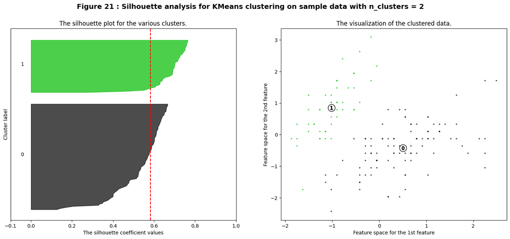

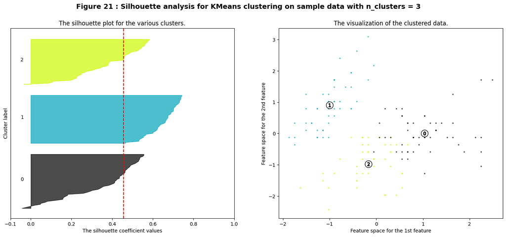

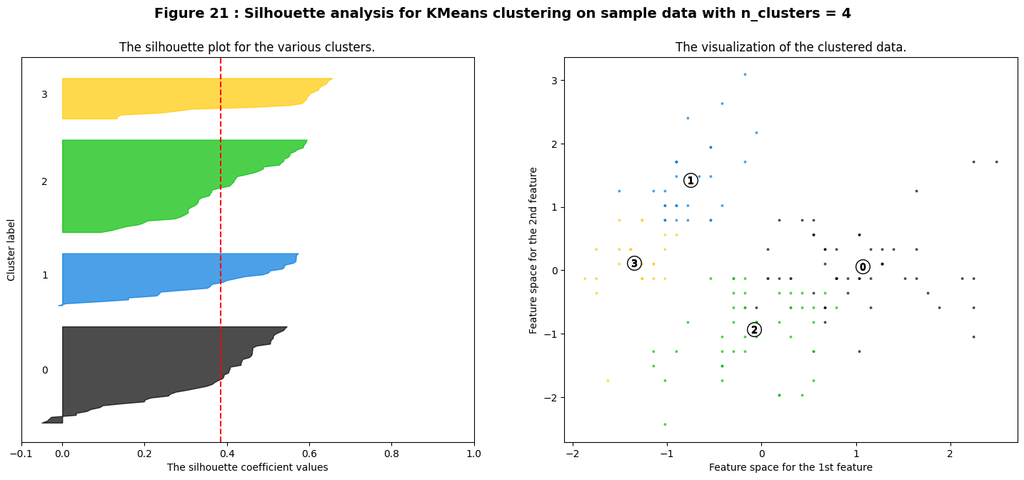

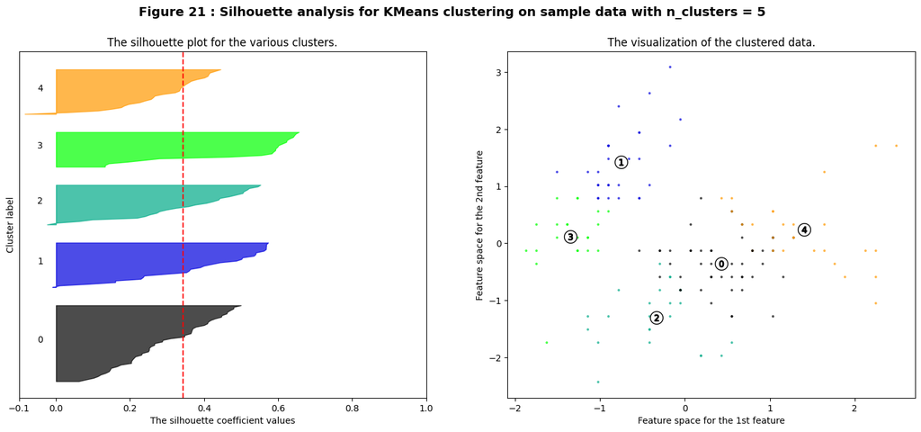

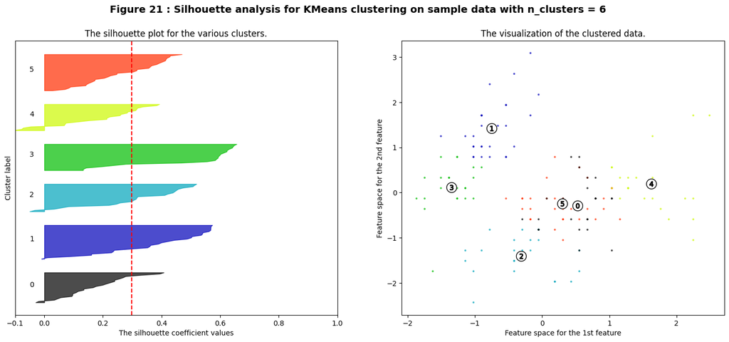

```python
#Create a silhouette plot

range_n_clusters = [2, 3, 4, 5, 6]

# Assuming iris_df2_scaled contains the standardized data
X2 = iris_df2_scaled

for n_clusters in range_n_clusters:
    # Create a subplot with 1 row and 2 columns
    fig, (ax1, ax2) = plt.subplots(1, 2)
    fig.set_size_inches(18, 7)

    # The 1st subplot is the silhouette plot
    # The silhouette coefficient can range from -1, 1 but in this example all
    # lie within [-0.1, 1]
    ax1.set_xlim([-0.1, 1])
    # The (n_clusters+1)*10 is for inserting blank space between silhouette
    # plots of individual clusters, to demarcate them clearly.
    ax1.set_ylim([0, len(X2) + (n_clusters + 1) * 10])

    # # Initialize the KMeans clusterer with the specified number of clusters
    # seed of 10 for reproducibility.
    clusterer = KMeans(n_clusters=n_clusters, random_state=10)
    cluster_labels = clusterer.fit_predict(X2)

    # The silhouette_score gives the average value for all the samples.
    # This gives a perspective into the density and separation of the formed
    # clusters
    silhouette_avg = silhouette_score(X2, cluster_labels)
    print(
        "For n_clusters =",
        n_clusters,
        "The average silhouette_score is :",
        silhouette_avg,
    )

    # Compute the silhouette scores for each sample
    sample_silhouette_values = silhouette_samples(X2, cluster_labels)

    y_lower = 10
    for i in range(n_clusters):
        # Aggregate the silhouette scores for samples belonging to
        # cluster i, and sort them
        ith_cluster_silhouette_values = sample_silhouette_values[cluster_labels == i]

        ith_cluster_silhouette_values.sort()

        size_cluster_i = ith_cluster_silhouette_values.shape[0]
        y_upper = y_lower + size_cluster_i

        color = cm.nipy_spectral(float(i) / n_clusters)
        ax1.fill_betweenx(
            np.arange(y_lower, y_upper),
            0,
            ith_cluster_silhouette_values,
            facecolor=color,
            edgecolor=color,
            alpha=0.7,
        )

        # Label the silhouette plots with their cluster numbers at the middle
        ax1.text(-0.05, y_lower + 0.5 * size_cluster_i, str(i))

        # Compute the new y_lower for next plot
        y_lower = y_upper + 10  # 10 for the 0 samples

    ax1.set_title("The silhouette plot for the various clusters.")
    ax1.set_xlabel("The silhouette coefficient values")
    ax1.set_ylabel("Cluster label")

    # The vertical line for average silhouette score of all the values
    ax1.axvline(x=silhouette_avg, color="red", linestyle="--")

    ax1.set_yticks([])  # Clear the yaxis labels / ticks
    ax1.set_xticks([-0.1, 0, 0.2, 0.4, 0.6, 0.8, 1])

    # 2nd Plot showing the actual clusters formed by KMeans
    colors = cm.nipy_spectral(cluster_labels.astype(float) / n_clusters)
    ax2.scatter(
        X2[:, 0], X2[:, 1], marker=".", s=30, lw=0, alpha=0.7, c=colors, edgecolor="k"
    )

    # Labeling the clusters
    centers = clusterer.cluster_centers_
    # Draw white circles at cluster centers
    ax2.scatter(
        centers[:, 0],
        centers[:, 1],
        marker="o",
        c="white",
        alpha=1,
        s=200,
        edgecolor="k",
    )

    for i, c in enumerate(centers):
        ax2.scatter(c[0], c[1], marker="$%d$" % i, alpha=1, s=50, edgecolor="k")

    ax2.set_title("The visualization of the clustered data.")
    ax2.set_xlabel("Feature space for the 1st feature")
    ax2.set_ylabel("Feature space for the 2nd feature")

    # General title for the entire plot to indicate KMeans analysis
    plt.suptitle(
        "Figure 21 : Silhouette analysis for KMeans clustering on sample data with n_clusters = %d"
        % n_clusters,
        fontsize=14,
        fontweight="bold",
    )
plt.savefig('Figure21_silhouette_analysis_for_KMeans_clustering_on_sample_data_with_n_clusters.png', dpi= 300)

plt.show()
```

### Explanation of the Methods Used to Determine the Optimal Number of Clusters

In unsupervised clustering analysis, several techniques are available to assess the optimal number of groups. Two complementary approaches are used here: **the Elbow Method** and **Silhouette Analysis**. These techniques help evaluate the quality of the clustering results, particularly when using algorithms such as KMeans.

## 1. Elbow Method

**Principle**:  
The Elbow Method is based on analyzing **intra-cluster inertia**, which is the sum of squared distances between each point and the center of its assigned cluster.  
As the number of clusters increases, the total inertia naturally decreases because the clusters become more compact. However, beyond a certain point, adding more clusters only marginally reduces the inertia.  
This inflection point, referred to as the **"elbow"**, indicates the **optimal number of clusters**.

**How to use**:

- The x-axis represents the number of clusters `k`, and the y-axis represents the total inertia.
- The elbow point is visually identified as the point where the inertia curve starts to flatten.
- This point reflects the best compromise between **internal cohesion** and **model simplicity**.

**Advantages**:

- Simple to implement and interpret.

**Limitations**:

- In some cases, the elbow may not be clearly visible, making it difficult to decide on the optimal number of clusters.

## 2. Silhouette Analysis

**Principle**:  
Silhouette analysis evaluates the **quality of cluster assignments** by comparing:

- The average distance between a point and all other points in the same cluster (cohesion),
- And the average distance to points in the nearest neighboring cluster (separation).

**Interpretation of silhouette scores**:

- Close to **+1**: The point is well assigned and far from other clusters.
- Around **0**: The point lies on the boundary between two clusters.
- Negative values: The point may have been assigned to the wrong cluster.

**How to use**:

- The x-axis shows the silhouette score (ranging from -1 to 1).
- Each cluster is represented by a horizontal area; the width indicates the quality and consistency of the cluster.
- The overall average silhouette score provides a quantitative assessment of clustering quality across different values of `k`.

**Advantages**:

- Offers a quantitative measure of clustering quality.
- Provides a finer analysis compared to inertia alone.

**Limitations**:

- May be less effective when clusters have irregular shapes or very different densities.

## Comparison of the Two Methods

| Criterion | Elbow Method | Silhouette Analysis |
| --- | --- | --- |
| **Objective** | Minimize inertia | Maximize cluster separation quality |
| **Measurement type** | Internal cohesion only | Cohesion and separation combined |
| **Ease of interpretation** | Medium (depends on curve clarity) | High (direct numeric interpretation) |
| **Focus** | Inertia reduction | Cluster separation and compactness |

## Conclusion

The **Elbow Method** offers a quick first estimation of the number of clusters based on the inertia curve. It is simple but may lack precision if no clear elbow is visible.

**Silhouette Analysis** provides a more detailed and robust evaluation, taking into account both the compactness within clusters and their separation from each other. It is particularly valuable for validating or refining the cluster count suggested by the elbow method.

**Using both methods together** is considered best practice when validating clustering results and selecting the most appropriate number of clusters.